# Maximum Likelihood

FW8051 Statistics for Ecologists

## Learning Objectives

- Understand how to use Maximum Likelihood to estimate parameters in statistical models
- Understand how to create confidence intervals for parameters estimated using Maximum Likelihood

## Estimation

We’ve covered a number of statistical distributions, described by a small set of parameters.

- How do we determine appropriate values of the parameters?
- How do we incorporate the effects of covariates?

Methods of estimation:

- Least squares
- Maximum likelihood
- Bayesian methods

Example from Crawley 2002. Statistical Computing and also his The R Book (2007).

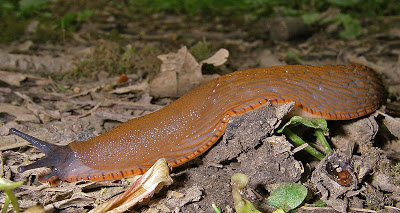

- Counted slugs in 2 fields (rookery, nursery)
- 40 observations in each

## Barplot

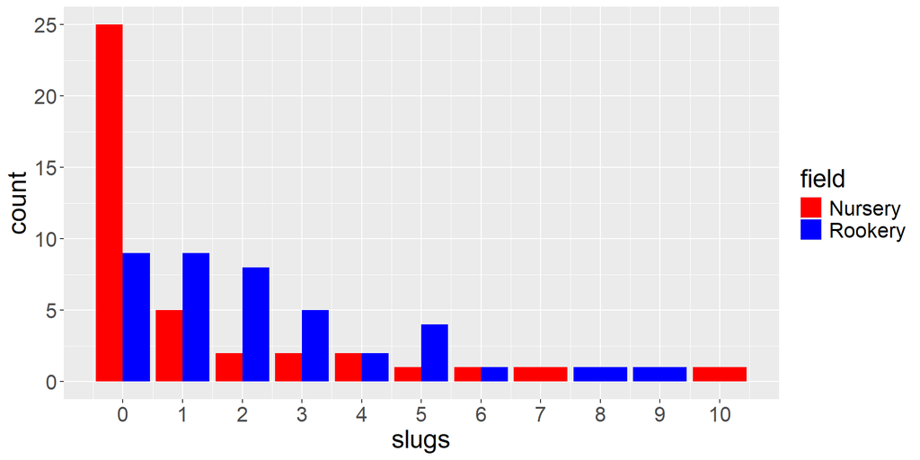

```r
ggplot(slugs, aes(slugs, fill=field))+
  geom_bar(position=position_dodge())+
  theme(text = element_text(size=20))+
   scale_fill_manual(values=c("red", "blue"))+
   scale_x_continuous(breaks=seq(0,11,1))
```

## Hypothesis test

What if we want to use a t-test to test $H_0: \mu_{rookery} = \mu_{nursery}$? What do we have to assume?

- The data are normally distributed or sample size is “large enough” for the CLT to apply

Are these assumptions reasonable in light of:

- We have counts (discrete data)
- There were 40 tiles in each of the 2 grasslands (field, nursery)

…maybe ($n = 30$ is a common rule for CLT to apply)

Also, side note, is this an interesting hypothesis to test?

## Alternative Statistical Distributions

Are there other, more appropriate statistical distributions we could use (instead of Gaussian)?

*Given that we have count data, we might consider a Poisson or Negative Binomial distribution for the data*

We could assume:

- Nursery $\sim Poisson(\lambda_1)$
- Rookery $\sim Poisson(\lambda_2)$

Test whether $\lambda_1 = \lambda_2$

How would we estimate the parameters?

Lets start with the simper case of $Y_i \sim Poisson(\lambda)$ (ignoring field type)

## Maximum Likelihood

Start by writing down a probability statement regarding the data.

Consider the first data point from the Nursery (3 slugs):

$P(X = 3) = \frac{\exp(-\lambda )(\lambda)^3}{3!}$ if the counts are Poisson distributed

or

$P(X = 3) = {3+\theta-1 \choose 3}\left(\frac{\theta}{\mu+\theta}\right)^{\theta}\left(\frac{\mu}{\mu+\theta}\right)^3$ if NegBinomial

What about the other observations?

## Constructing the Likelihood

Assume the data come from a random sample, and that the points are independent. Then:

$P(X_1$ =3 & $X_2 = 0$ & $\cdots X_{40}=4)$ = $P(X_1=3)P(X_2=0)\cdots P(X_{40}=4)$

= $\frac{\exp(-\lambda )(\lambda)^3}{3!}\frac{\exp(-\lambda )(\lambda)^0}{0!}\cdots \frac{\exp(-\lambda )(\lambda)^4}{4!}$

## More Generally

We obtain a random sample of $n$ observations from some statistical distribution.

Write down the probability of obtaining the data:

$P(X_1 =x_1, X_2=x_2, \ldots, X_n = x_n)$ = $P(X_1=x_1)P(X_2=x_2)\cdots P(X_n=x_n)$

= $\prod_{i=1}^n P(X_i = x_i)$

For the Poisson distribution:

$$L(\lambda; x_1, x_2, \ldots, x_n) = \prod_{i=1}^n\frac{\lambda^{x_i}\exp(-\lambda)}{x_i!}$$

$$=\frac{\exp(-\lambda )(\lambda)^{x_1}}{X_1!}\frac{\exp(-\lambda)(\lambda)^{x_2}}{x_2!}\cdots \frac{\exp(-\lambda )(\lambda)^{x_n}}{x_n!}$$

$$=\frac{\exp(-n\lambda)(\lambda)^{\sum_{i=1}^nx_i}}{x_1!x_2!\cdots x_n!}$$

This gives us the Likelihood of the data!

## Likelihood

For discrete distributions, the likelihood gives us the probability of obtaining the observed data for a particular set of parameters (in this case, $\lambda$).

$$P(data; \lambda) = \frac{\exp(-n\lambda)(\lambda)^{\sum_{i=1}^nx_i}}{x_1!x_2!\cdots x_n!} = L(\lambda; data)$$

P(data; parameter):

- Views the data as random, the parameter as fixed.

Likelihood(parameters; data):

- Conditions on the data and considers probability as a function of the parameter.

The maximum likelihood estimate is the value of the parameter, $\lambda$, that maximizes the likelihood (*makes the the observed data most likely*)

## Maximum Likelhood

$$L(\lambda; x_1, x_2, \ldots, x_n) = \prod_{i=1}^n\frac{\lambda^{x_i}\exp(-\lambda)}{x_i!}$$

How can we find the value of $\lambda$ that maximizes $L(\lambda; x_1, x_2, \ldots, x_n)$?

Calculus (take derivatives with respect to $\lambda$ and set = 0).

## Log-likelihood

For practical and theoretical reasons, we usually work with the log-likelihood (maximizing the log-likelihood is equivalent to maximizing the likelihood)

$$logL(\lambda; x_1, x_2, \ldots, x_n)= log(L(\lambda; x_1, x_2, \ldots, x_n)) = \log(\prod_{i=1}^n P(X_i = x_i))$$

$= \sum_{i=1}^n log(P(X_i = x_i))$

For the Poisson model:

$logL(\lambda; x_1, x_2, \ldots, x_n) = -n\lambda +\log(\lambda)\sum_{i=1}^n X_i - \sum_{i=1}^n \log(x_i!)$

To maximize, take derivatives and set the expression = 0, giving: …

$$-n + \frac{\sum_{i=1}^n X_i}{\lambda} = 0$$

$$\Rightarrow \hat{\lambda}=\sum_{i=1}^n \frac{X_i}{n}$$

## Some notes

To verify that $\hat{\lambda}$ maximizes (rather than minimizes) $logL(\lambda| x)$:

- Verify that the $\frac{\partial^2 logL(\lambda; x)}{\partial \lambda^2}$ evaluated at $\lambda = \hat{\lambda} =\bar{x} < 0$

Note: If $X \sim$ Poisson($\lambda$), $E[X] = \lambda$

- It makes sense to estimate $\lambda$ by the sample mean!

Some constants, e.g., $\sum_{i=1}^n \log(x_i!)$ do not matter when maximizing the likelihood

- Statistical software may drop/ignore these
- Can matter when comparing models for different probability distributions using AIC

## Finding the “best” value of $\lambda$

What if we do not remember calculus? How can we find the value of $\lambda$ that maximizes:

$$L(\lambda; x_1, x_2, \ldots, x_n) = \prod_{i=1}^n\frac{\lambda^{x_i}\exp(-\lambda)}{x_i!}$$

Graph this expression for different values of $\lambda$

[Excel in-class exercise]

## Finding the “best” values for $\lambda_1$ and $\lambda_2$

What if we had a function of more than 1 parameter? How could we numerically find the value of $\lambda$ that maximizes:

$$L(\lambda_1, \lambda_2; x_1, x_2, \ldots, x_n) = \prod_{i=1}^{n_{field}}\frac{\lambda_1^{x_i}\exp(-\lambda_{1})}{x_i!} \prod_{j=1}^{n_{rookery}}\frac{\lambda_2^{x_j}\exp(-\lambda_{2})}{x_j!}$$

Use *solver* in Excel or `optim` (or `glm`) in R

[In-class exercise R]

## Optim?

Tadpole predation: Example 6.3.1.1 from Bolker et al.(2008)<sup>1</sup>

$$p = \frac{a}{1+ahN}$$

$$k \sim Binomial(p,N)$$

- $N$ = number of tadpoles in a tank
- $k$ = number eaten by predators

We will come back to this or a similar example (in this section and later after introducing Bayesian methods).

[^1]: Bolker, B.M. 2008. Ecological Models and Data in R. Princeton University Press, Oxford, UK.

## Properties of Maximum Likelihood Estimators

$\hat{\theta}$ = maximum likelihood estimate of $\theta$.

For large $n$ (asymptotically):

- Maximum likelihood estimators are unbiased<sup>1</sup>
- Have minimum variance among estimators
- Will be normally distributed: $\hat{\theta} \sim N(\theta, I^{-1}(\theta))$

$I(\theta)$ is called the Information matrix

[^2]: Not always true for small $n$. For example, $\sigma^2_{MLE} = \sum (x_i-\mu)^2/n$ (biased by a factor of $n/(n-1)$)

## Information Matrix

Observed information matrix, observed $I(\theta)$ = $-\frac{\partial^2 logL(\theta)}{\partial \theta^2}$ evaluated at $\theta = \hat{\theta}$

Estimated information matrix, expected $I(\theta)$ = $E\left(-\frac{\partial^2 logL(\theta)}{\partial \theta^2}\right)$ evaluated at $\theta = \hat{\theta}$

The matrix of second derivatives of logL with respect to $\theta$ is called the Hessian:

Hessian($\theta) = \left[\frac{\partial^2 logL(\theta)}{\partial \theta^2}\right]$

## Observed Information Matrix

- Used to numerically maximize functions (get for “free”) (note: typically we *minimize* -logL rather than maximize logL, so the minus sign is already included)
- Inverse of observed information matrix is usually what is reported as $var(\hat{\theta})$ by statistical software

## Hessian

The Hessian($\theta$) = $\left[\frac{\partial^2 logL(\theta)}{\partial \theta^2}\right]$ describes curvature in the log-likelihood curve (surface). If $\left[\frac{\partial^2 logL(\theta)}{\partial \theta^2}\right]$ is close to 0:

- The likelihood surface is flat
- LogL is similar across a range of parameter values

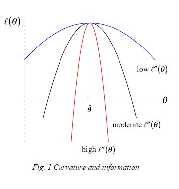

Leads to larger confidence intervals since $\widehat{var}(\hat{\theta}) = I^{-1}(\theta) =$ Hessian$^{-1}(\theta)$

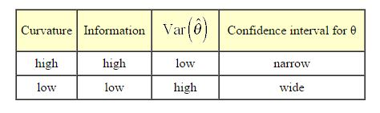

## Likelihood Ratio Test

A likelihood ratio test can be used to test nested models with:

- The same probability generating mechanism (i.e., same statistical distribution)
- All of the same parameters, except that in one model some parameters are set to specific values (typically 0)

Slug data example:

Full model:

- $Y_i |$ Nursery $\sim Poisson(\lambda_1)$
- $Y_i |$ Rookery $\sim Poisson(\lambda_2)$

Reduced model:

- $Y_i \sim Poisson(\lambda)$ (i.e., $\lambda_2= \lambda_1$)

## Likelihood Ratio Test

Test statistic:

$$LR = 2log\left[\frac{L(\lambda_1, \lambda_2 | Y)}{L(\lambda | Y)}\right] = 2[logL(\lambda_1, \lambda_2 | Y)-logL(\lambda | Y)]$$

Null distribution (appropriate when $n$ is large):

$$LR \sim \chi^2_1$$

and more generally $\chi^2_p$, where $p$ is the difference in the number of parameters in the two models (See Section 10.9 in book).

## Profile Likelihood CIs

Can “invert” the LR test to get profile likelihood-based confidence intervals. Consider generating a CI for $\lambda$ under the common $\lambda$ model.

We could use the likelihood ratio test to evaluate $H_0: \lambda = \lambda_0$ vs. $H_A: \lambda \ne \lambda_0$:

$$LR = 2log\left[\frac{L(\hat{\lambda} | Y)}{L(\lambda_0 | Y)}\right] \sim \chi^2_1$$

where $\hat{\lambda}$ is the MLE of $\lambda$.

- Reject $\lambda = \lambda_0$ at $\alpha=0.05$ if LR $>\chi^2_1(0.95)$, where $\chi^2_1(0.95)$ is the 95% of the $\chi^2_1$ distribution.
- Fail to reject if LR $<\chi^2_1(0.95)$ (these values are plausible, given the data)

CI for $\lambda$: include all values for which we do not reject the null hypothesis

## Profile Likelihood Intervals

So, include in our CI all values of $\lambda$ that lie within $\chi^2_{1}(0.95)=$ `qchisq(alpha, df=1)/2` = 1.92 units of the maximum.

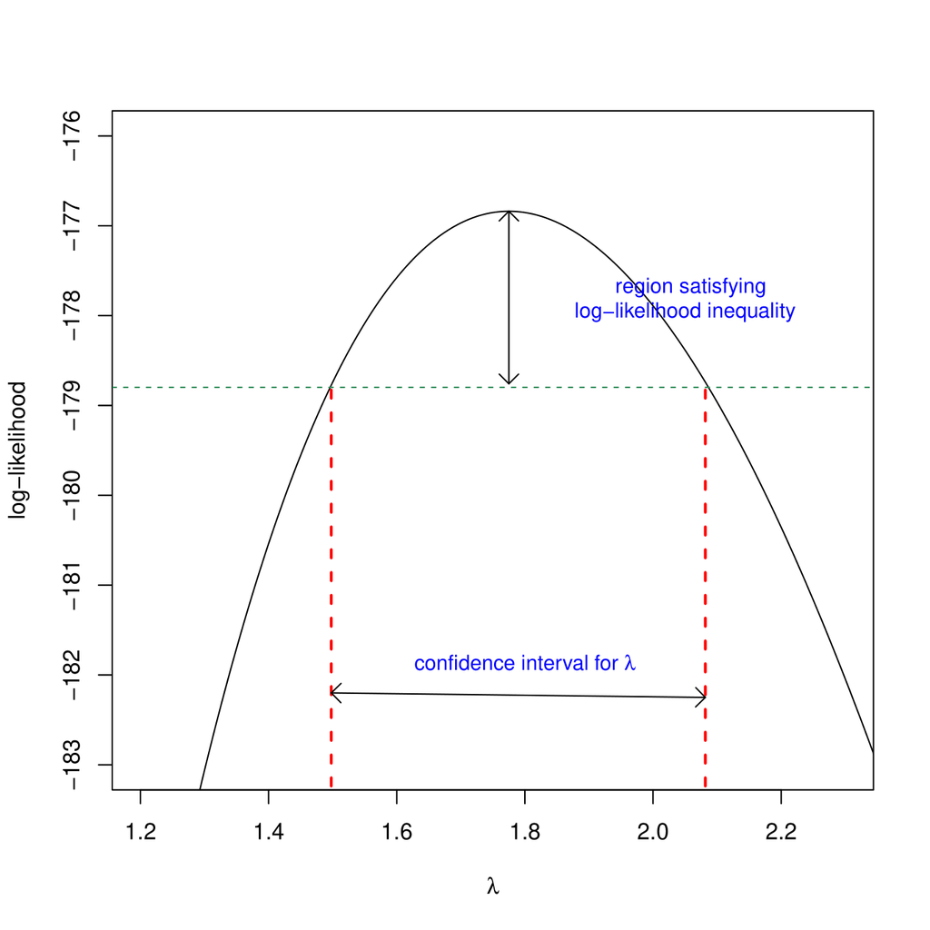

## Profile Likelihood Intervals

- Can extend to multi-parameter models
- Typically more accurate than normal-based CIs (Wald intervals) when $n$ is small.

See Chapter 6 in Bolker’s book (listed in **Readings** section on Canvas).

## Least Squares and MLE

For Normally distributed data:

$L(\mu, \sigma^2; y_1, y_2, \ldots, y_n) = \prod_{i=1}^n \frac{1}{\sqrt{2\pi}\sigma}\exp\left(-\frac{(y_i-\mu)^2}{2\sigma^2}\right)$

With linear regression, we assume $Y_i \sim N(\beta_0 + x_i\beta_1, \sigma^2)$, so…

$L(\beta_0, \beta_1, \sigma; x) = \prod_{i=1}^n \frac{1}{\sqrt{2\pi}\sigma}\exp\left(-\frac{(y_i-\beta_0+x_i\beta_1)^2}{2\sigma^2}\right) =\frac{1}{(\sqrt{2\pi}\sigma)^n}\exp\left(-\sum_{i=1}^n\frac{(y_i-\beta_0+x_i\beta_1)^2}{2\sigma^2}\right)$

$\Rightarrow logL =-nlog(\sigma) - \frac{n}{2}log(2\pi) -\sum_{i=1}^n\frac{(y_i-\beta_0+x_i\beta_1)^2}{2\sigma^2}$

$\Rightarrow$ maximizing logL $\Rightarrow$ minimizing $\sum_{i=1}^n\frac{(y_i-\beta_0+x_i\beta_1)^2}{2\sigma^2}$

or, equivalently $\sum_{i=1}^n(y_i-\beta_0-x_i\beta_1)^2$